# Lecture 2

Fitting and Choosing Models

## Components of time series data

- traditional time series analysis tries to divide time series into a limited number of components, each one a function of time $t$
  - trend
  - season
  - other cyclic components
  - noise
- noise is what we consider the remaining variability that cannot be explained by the other components

## Components of time series data

- there is not the one correct decomposition
- the choice of components and how we try to model them depends on what we know about the process
  - say we know that daily mean temperature (at a certain location) follows a seasonal periodicity, so we could try to model this component with a periodic function of time $f(t)$, like a sinus function
  - there could also be another (overlaying) trend, e.g., for temperature a long term increase (climate change)
- the following slide shows a similar example using CO2 measurements

## Components of time series data (here CO2)

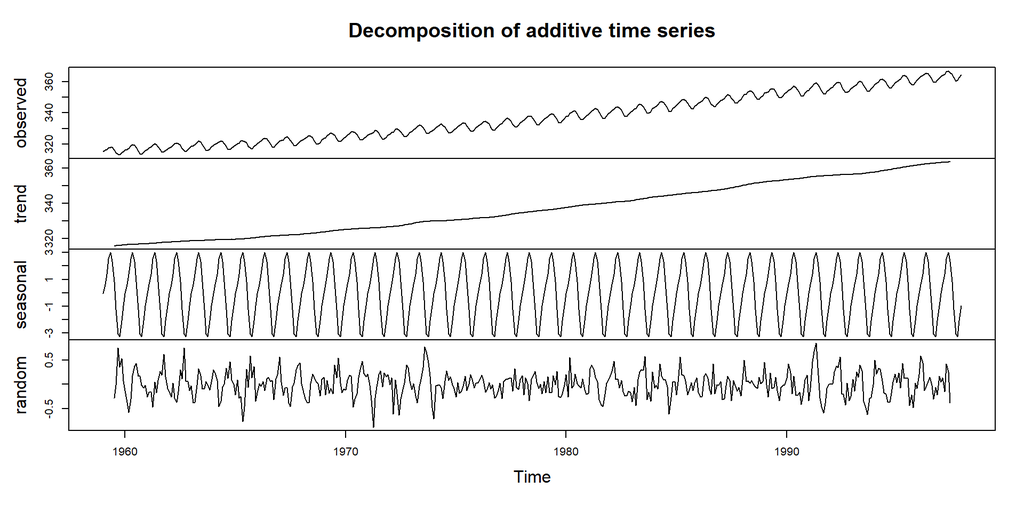

```r
library(graphics) #load package including data
data(co2) # load data
m=decompose(co2)
plot(m)
```

## Components of time series data

- in this course we will build on a basic additive component model

$$y(t) = m(t) + e(t)$$

- $m(t)$ is the deterministic component, which we can explain by, e.g., a constant increase (linear trend), a periodic function, a combination of both, …
- $e(t)$ is the stochastic component, that may or may not be random (white noise)
  - cannot be explained by the deterministic functions we know (in the context of this course)
  - can have different forms, can show patterns
  - might be modelled by, e.g., AR(p) or MA(q) processes

## Back to the temperature series

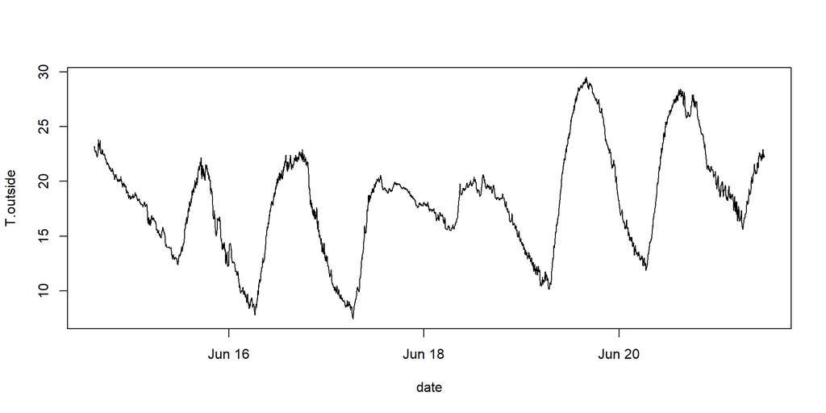

## Removing the diurnal periodicity

Assuming this is a sinus function,
$$\alpha_1 + \alpha_2 \sin(t + \alpha_3)$$
, we need non-linear regression (function is non-linear in $\alpha_3$)

```r
attach(meteo) # so we can use variable names directly:
f = function(x) sum((T.outside - (x[1]+x[2]*sin(pi*(hours+x[3])/12)))^2)
nlm(f,c(0,0,0))
```

```
$minimum
[1] 108956.1

$estimate
[1] 18.189544 -4.904740  1.604442

$gradient
[1] -1.600031e-06 -9.790799e-05  1.904651e-04

$code
[1] 1

$iterations
[1] 9
```

## Removing the diurnal periodicity

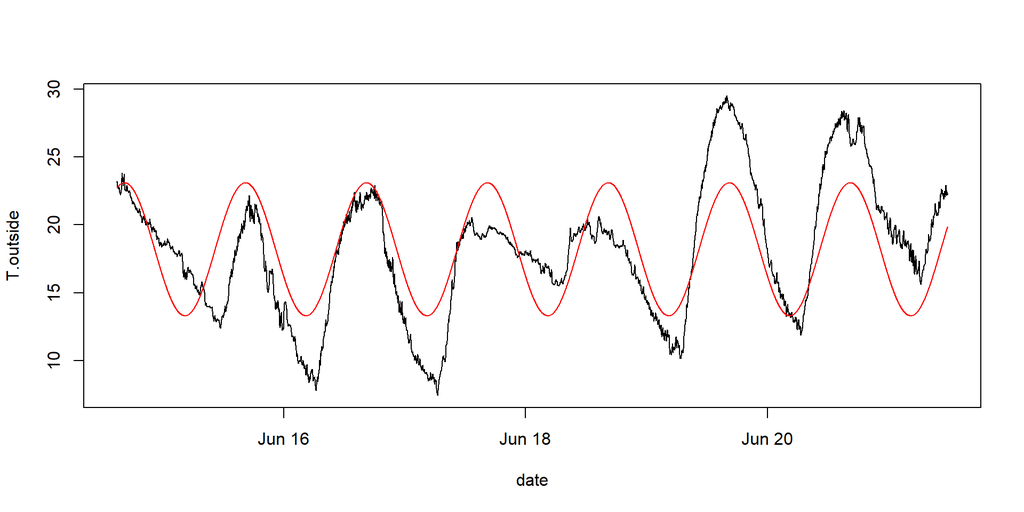

```r
# plot data and trend:
plot(T.outside~date,meteo,type='l')
meteo$T.per = 18.2-4.9*sin(pi*(meteo$hours+1.6)/12) #use parameters fitted before (previous slide)
lines(T.per~date,meteo,col='red')
```

## Temperature anomaly

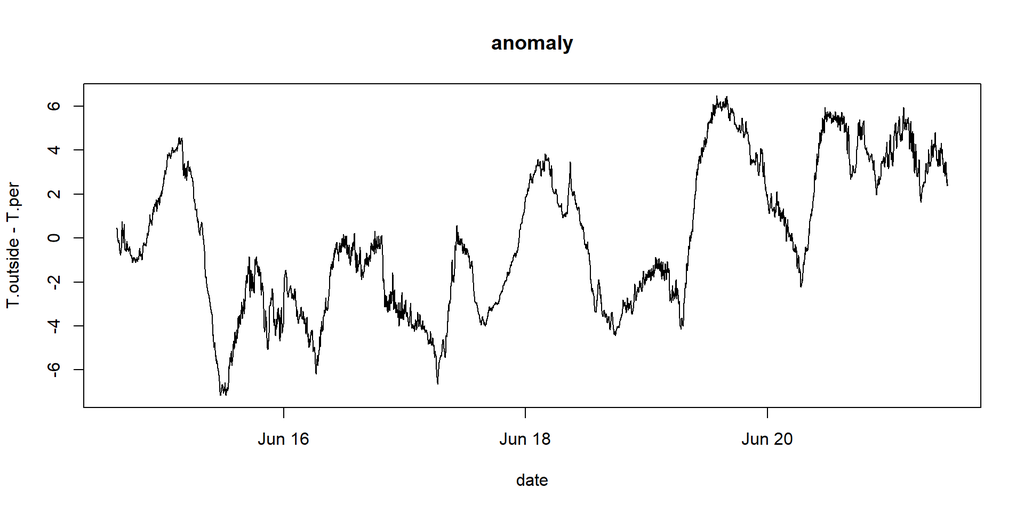

```r
plot(T.outside-T.per~date, meteo, type='l')
title("anomaly")
```

## Temperature anomaly

- Can we also make estimates of this anomaly?

## Temperature anomaly

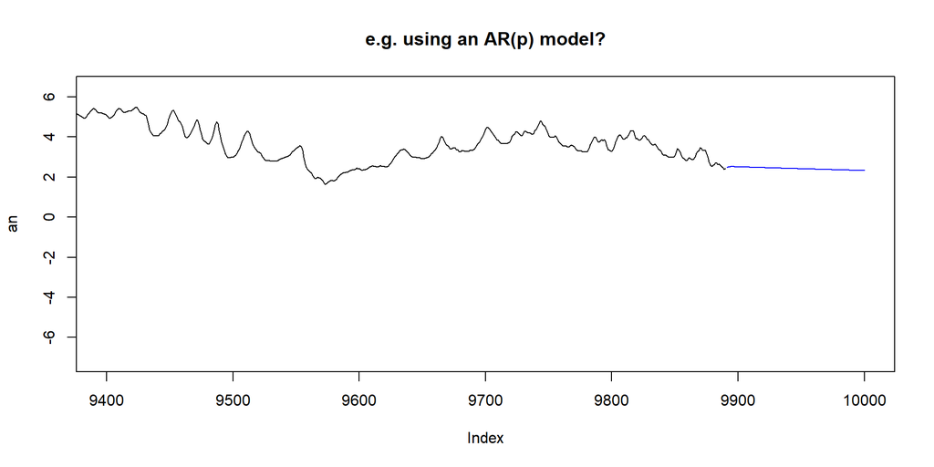

## What can we do with such models?

- try to find out which model fits best (model selection)
- learn how they were/could have been generated
- predict future observations (estimation/prediction/forecasting)
- generate similar data ourselves (simulation)

## How to select a “best” model?

A possible approach is to find the minimum for *Akaike’s Information Criterion (AIC)* for ARMA($p,q$) models and series of length $n$:
$$AIC = \log \hat{\sigma}^2 + 2(p+q+1)/n$$
with $\hat{\sigma}^2$ the estimated residual (noise) variance.

Instead of finding a single best model using this single criterion, it may be better to select a small group of “best” models, and look at model diagnostics for each: is the residual white noise? does it have stationary variance?

Even better may be to keep a number of “fit” models and consider each as (equally?) suitable candidates.

## AIC for AR(p), and as as a function of $p$

```
 [1] -23547.93 -30235.42 -30713.51 -30772.31 -30815.14 -30816.35 -30818.27
 [8] -30818.39 -30817.82 -30815.84
```

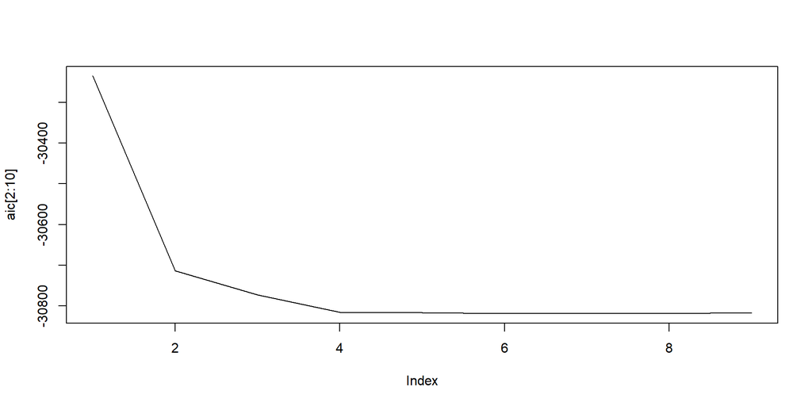

## Anomaly AIC as a function of $p$, for AR(p)

```
 [1] -23994.90 -30320.26 -30843.40 -30885.36 -30945.22 -30943.51 -30952.06
 [8] -30957.84 -30955.86 -30955.38
```

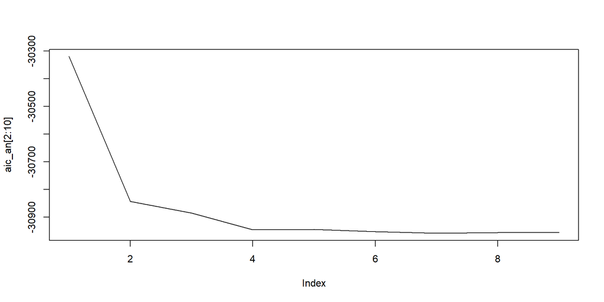

## Prediction, e.g. with AR(6) - 10 minutes

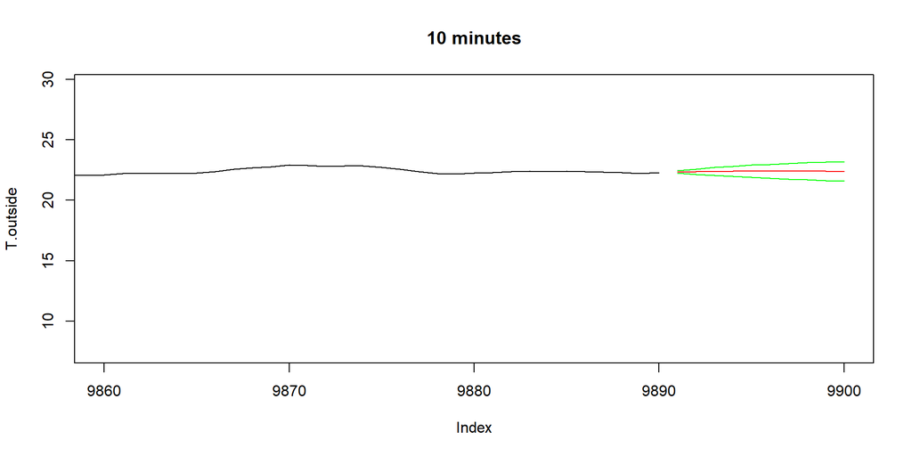

```r
# Prediction, e.g. with AR(6)
x = arima(T.outside, c(6,0,0))

pltpred = function(xlim, Title) {
  plot(T.outside, xlim = xlim, type='l')
  start = nrow(meteo) + 1
  pr = predict(x, n.ahead = xlim[2] - start + 1)
  lines(start:xlim[2], pr$pred, col='red')
  lines(start:xlim[2], pr$pred+2*pr$se, col='green')
  lines(start:xlim[2], pr$pred-2*pr$se, col='green')
  title(Title)
}
pltpred(c(9860, 9900), "10 minutes")
```

## Prediction of Anomaly, e.g. with AR(6) - 10 minutes

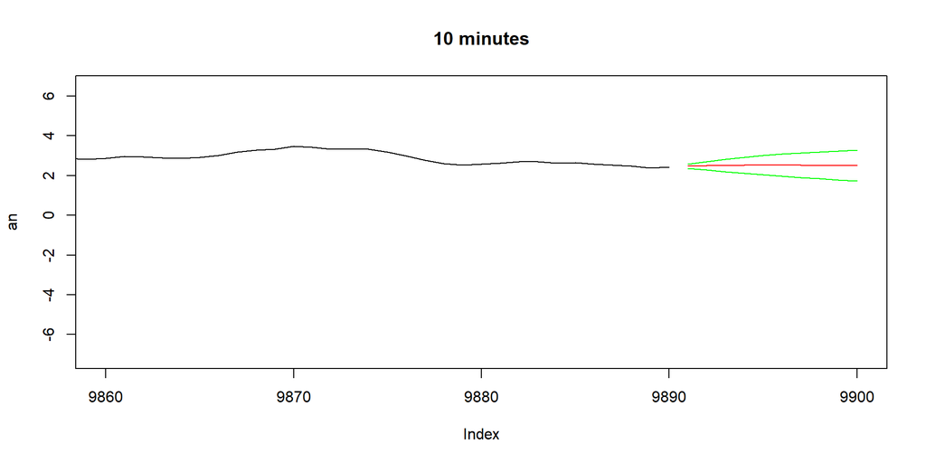

```r
# Prediction, e.g. with AR(6)
T.per = 18.2-4.9*sin(pi*(hours+1.6)/12)
an = T.outside - T.per
x2 = arima(an, c(6,0,0))

pltpred2 = function(xlim, Title) {
  plot(an, xlim = xlim, type='l')
  start = nrow(meteo) + 1
  pr = predict(x2, n.ahead = xlim[2] - start + 1)
  lines(start:xlim[2], pr$pred, col='red')
  lines(start:xlim[2], pr$pred+2*pr$se, col='green')
  lines(start:xlim[2], pr$pred-2*pr$se, col='green')
  title(Title)
}
pltpred2(c(9860, 9900), "10 minutes")
```

## Prediction, e.g. with AR(6) - 110 minutes

```r
pltpred(c(9400, 10000), "110 minutes")
```

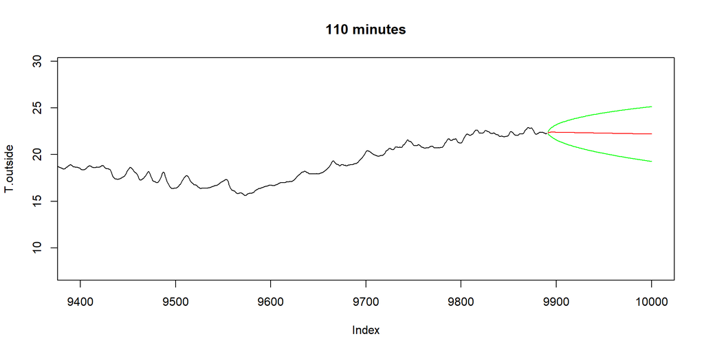

## Prediction of Anomaly, e.g. with AR(6) - 110 minutes

```r
pltpred2(c(9400, 10000), "110 minutes")
```

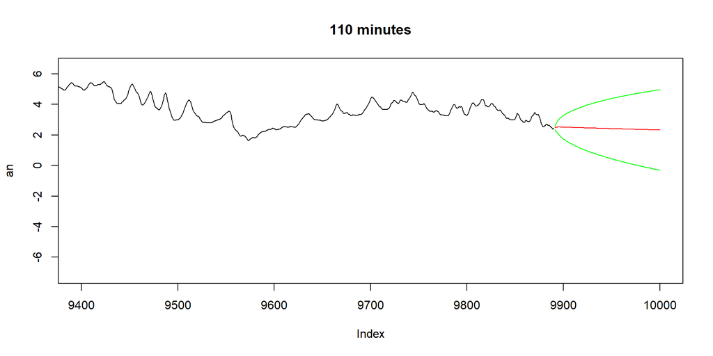

## Prediction, e.g. with AR(6) - 1 day

```r
pltpred(c(8000, 11330), "predicting 1 day")
```

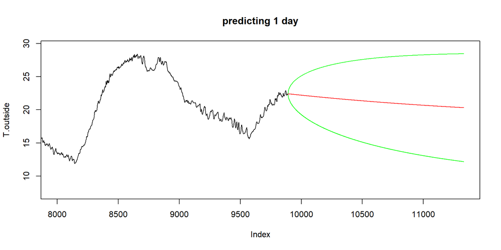

## Prediction of Anomaly, e.g. with AR(6) - 1 day

```r
pltpred2(c(8000, 11330), "predicting 1 day")
```

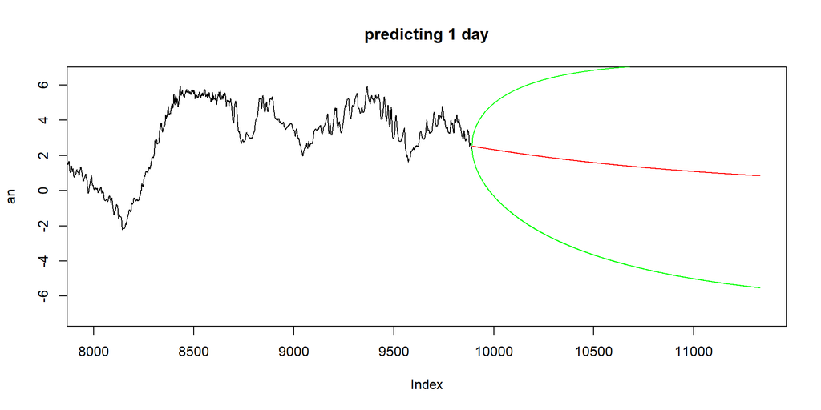

## Prediction, e.g. with AR(6) - 1 week

```r
pltpred(c(1, 19970), "predicting 1 week")
```

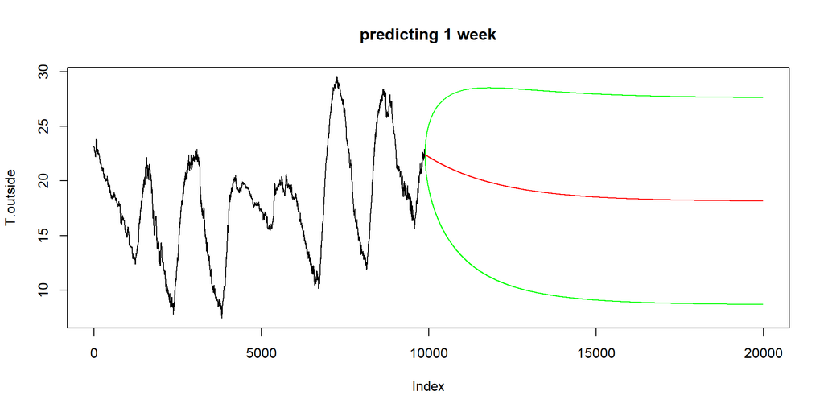

## Prediction of Anomaly, e.g. with AR(6) - 1 week

```r
pltpred2(c(1, 19970), "predicting 1 week")
```

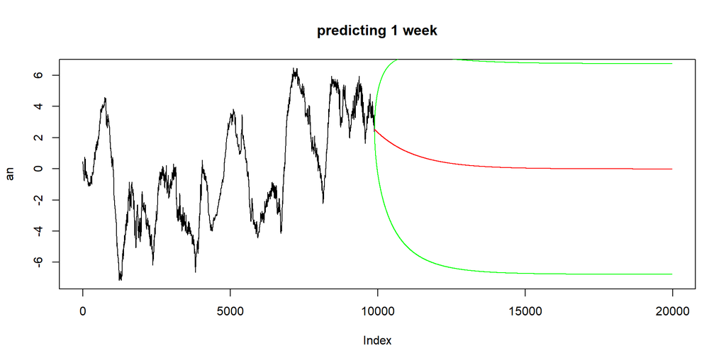

## Predicting 1 week: periodic trend + ar(6) for anomaly

Now that we have an idea of the trend and the anomaly, we can combine them to make predictions

## Predicting 1 week: periodic trend + ar(6) for anomaly

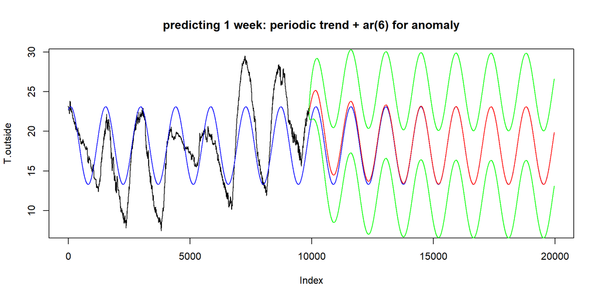

```r
plot(T.outside,xlim=c(1,19970), type='l')
x.an = arima(an, c(6,0,0)) # model the anomaly by AR(6)
x.pr = as.numeric(predict(x.an, 10080)$pred)
x.se = as.numeric(predict(x.an, 10080)$se)
hours.all = c(meteo$hours, max(meteo$hours) + (1:10080)/60)
T.per = 18.2-4.9*sin(pi*(hours.all+1.6)/12)
lines(T.per, col = 'blue')
hours.pr = c(max(meteo$hours) + (1:10080)/60)
T.pr = 18.2-4.9*sin(pi*(hours.pr+1.6)/12)
lines(9891:19970, T.pr+x.pr, col='red')
lines(9891:19970, T.pr+x.pr+2*x.se, col='green')
lines(9891:19970, T.pr+x.pr-2*x.se, col='green')
title("predicting 1 week: periodic trend + ar(6) for anomaly")
```

## Simulation with and without trend

We can also use these models to simulate data

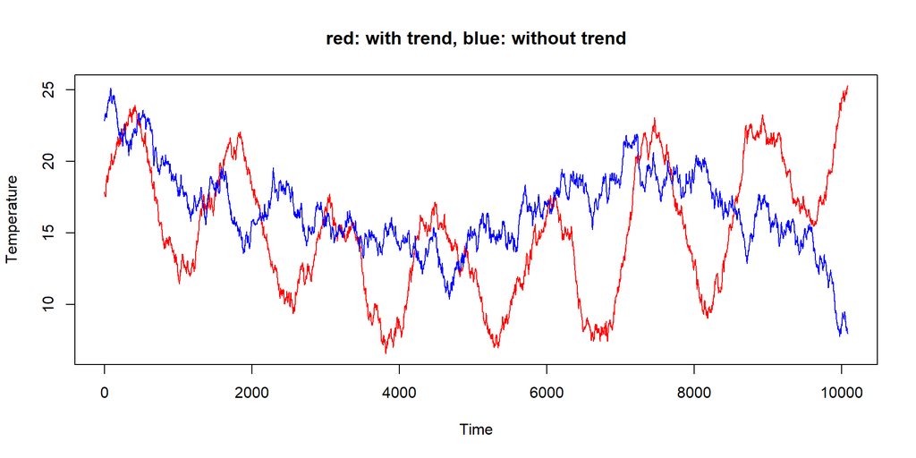

```r
x = arima(T.outside, c(6,0,0))
plot(T.pr + arima.sim(list(ar = x.an$coef[1:6]), 10080, sd = sqrt(0.002556)),
    col = 'red', ylab="Temperature")
lines(18+arima.sim(list(ar = x$coef[1:6]), 10080, sd=sqrt(0.002589)),
    col = 'blue')
title("red: with trend, blue: without trend")
```

## What can we learn from this?

Prediction/forecasting:

- AR(6) prediction is a compromise between the end of the series and the trend
- the closer we are to observations, the more similar the prediction is to the nearest (last) observation
- further in the future the prediction converges to the trend
- the more useful (realistic) the trend is, the more realistic the far-into-the-future prediction becomes
- the standard error of prediction increases when predictions are further in the future.

## A side note: fitting a phase with a linear model

A phase shift model $\alpha \sin(x + \phi)$ can also be modelled by  
$\alpha sin(x) + \beta cos(x)$; this is essentially a re-parameterization.

## A side note: fitting a phase with a linear model

A phase shift model $\alpha \sin(x + \phi)$ can also be modelled by  
$\alpha sin(x) + \beta cos(x)$; this is essentially a re-parameterization.

Try the following code:

```r
x = seq(0, 4*pi, length.out = 200) # x plotting range

sincos = function(dir, x) { # plot the combination of a sin+cos function, based on dir
    a = sin(dir)
    b = cos(dir)
    # three curves:
    plot(a * sin(x) + b * cos(x) ~ x, type = 'l', asp=1, col = 'green')
    lines(x, a * sin(x), col = 'red')
    lines(x, b * cos(x), col = 'blue')
    # legend:
    lines(c(10, 10+a), c(2,2), col = 'red')
    lines(c(10, 10), c(2,2+b), col = 'blue')
    arrows(x0 = 10, x1 = 10+a, y0 = 2, y1 = 2+b, .1, col = 'green')
    title("red: sin(x), blue: cos(x), green: sum")
}

for (d in seq(0, 2*pi, length.out = 100)) {
    sincos(d, x)
    Sys.sleep(.1)
}
```

## A side note: fitting a phase with a linear model

So, we can fit the same model by a different parameterization:

```r
nlm(f,c(0,0,0))$minimum
```

```
[1] 108956.1
```

```r
# [1] 108956
tt = pi * hours / 12
g = function(x) sum((T.outside - (x[1]+x[2]*sin(tt)+x[3]*cos(tt)))^2)
nlm(g,c(0,0,0))
```

```
$minimum
[1] 108956.1

$estimate
[1] 18.189544 -4.478379 -2.000148

$gradient
[1] -0.0003296063 -0.0024207812 -0.0012586475

$code
[1] 1

$iterations
[1] 5
```

## A side note: fitting a phase with a linear model

…which is a linear model, identical to:

```r
lm(T.outside~sin(tt)+cos(tt))
```

```
Call:
lm(formula = T.outside ~ sin(tt) + cos(tt))

Coefficients:
(Intercept)      sin(tt)      cos(tt)
     18.190       -4.478       -2.000
```

## Next lectures: how do we fit coefficients?

- we have now seen how to select models and fit them to the data using R-functions like `nlm()`
- in the next lectures, we will have a look at different methods that are used for this fitting (optimization)

## Sidetrack: time series analysis for satellite-based land use change detection

- Satellites continusouly observe the surface of the earth
- How can we use this information to detect and monitor changes like deforestration?
- Example dataset: MODIS 16 day vegetation index measaurements over the Brazilian amazon

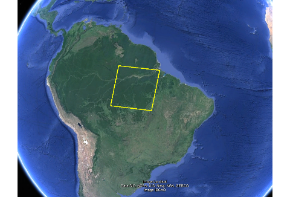

## A time-series of images

The EVI (enhanced vegetation index) is a one-dimensional index computed from near infrared, red, and blue reflection measurements. Values can be interpreted as “greenness” and range from -1 to 1.

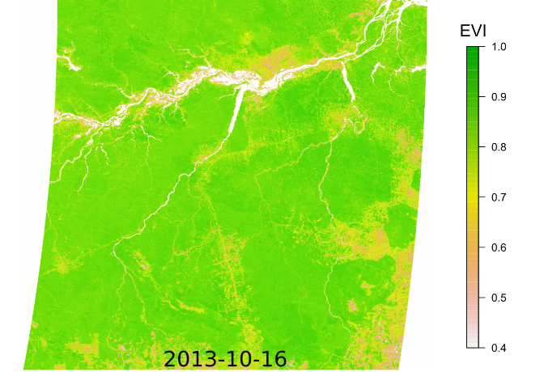

## A time-series of images

For each of the $1200^2$ pixels, we interpret the set of observations as time series.

Consider the general model:
$$y_t = T_t + S_t + R_t$$

- $T_t$ describes the trend
- $S_t$ describes seasonal effects
- $R_t$ describes remaining variation

We could be interested in both, changes in the trend and seasonality.

## Example analysis

An example series (1 pixel in forest area):

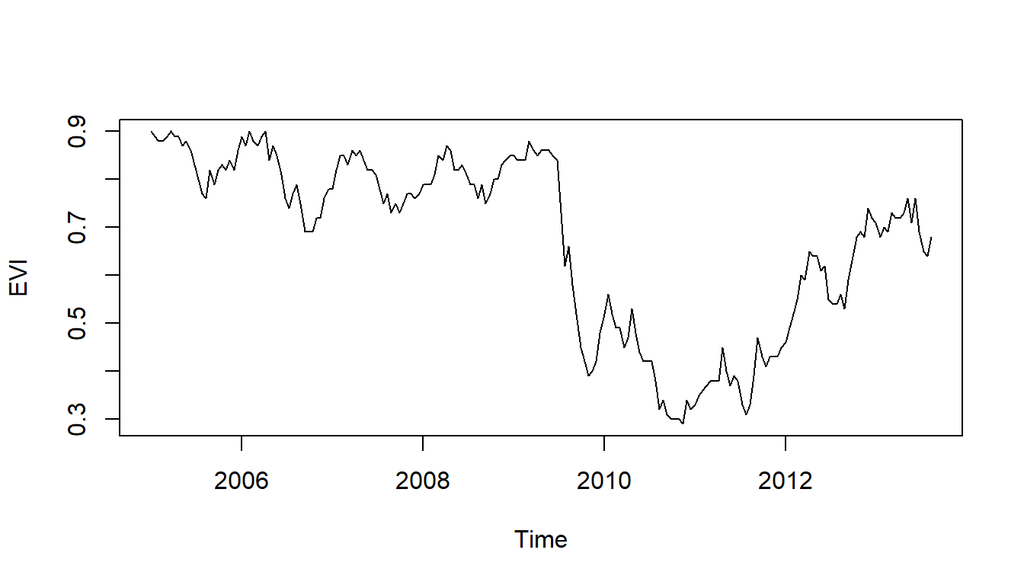

## Example analysis

We compute differences from the overall mean to center the series around 0.

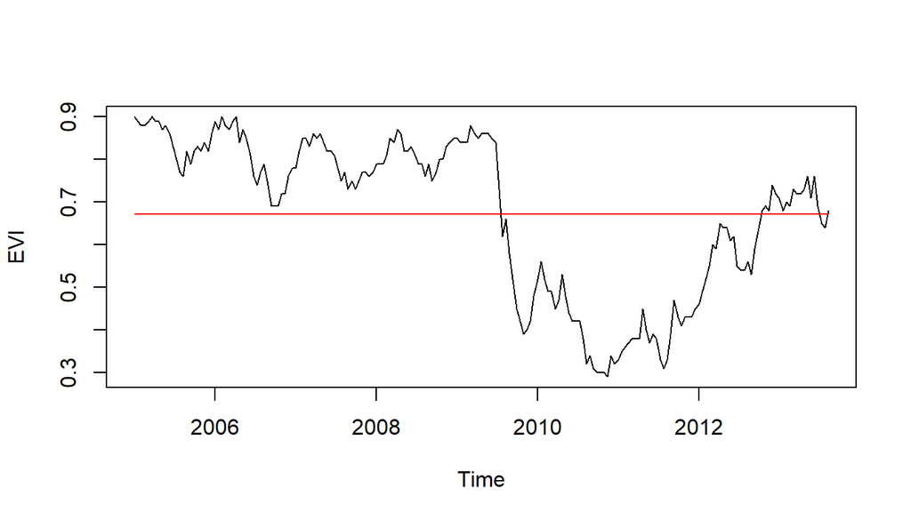

## Example analysis

We compute differences from the overall mean to center the series around 0.

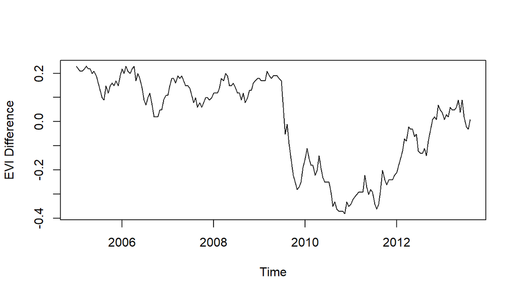

## Example analysis

We assume yearly seasonality and build seasonal sub-series:

$$\begin{aligned}
y_t^{(16)} &= (y_{2005,16},y_{2006,16},y_{2007,16},y_{2008,16}, ...) \\
y_t^{(32)} &= (y_{2005,32},y_{2006,32},y_{2007,32},y_{2008,32}, ...) \\
...
\end{aligned}$$
for which we simply compute mean values.

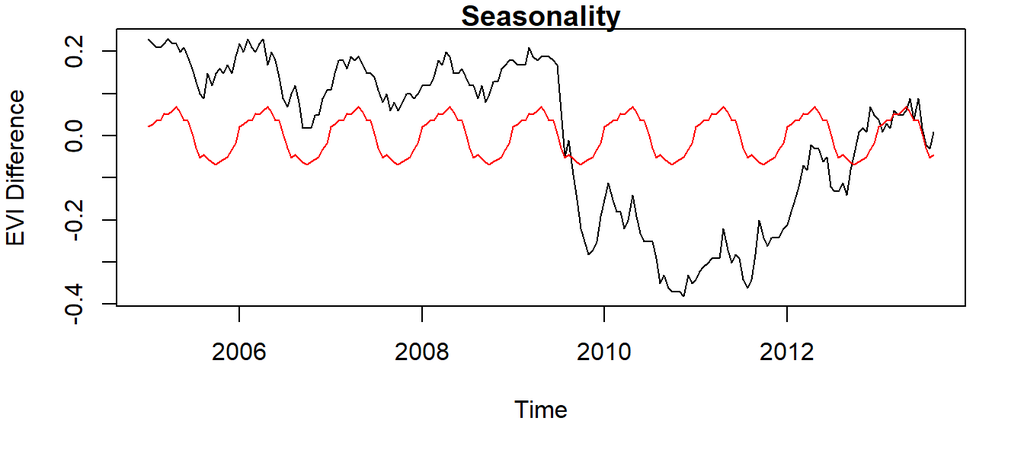

## Example analysis

After subtracting the seasonal component, the series looks like:

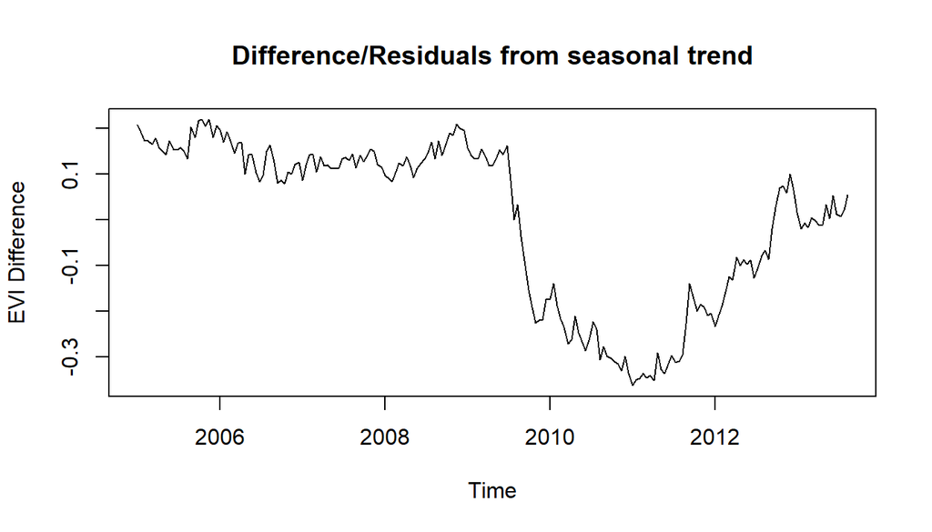

## Example analysis

After removing large parts of seasonality, we can study the trend of the data. Deforestation should be visible by abrupt changes in the trend structure. To test, whether there is a structural change, we assume the following linear regression model
$$T_t = \beta_0 + \beta_1 t$$
and hypothesize that the regression coefficients $\beta_0, \beta_1$ do not change in time.

## Example analysis

Fitting a global trend leads to:

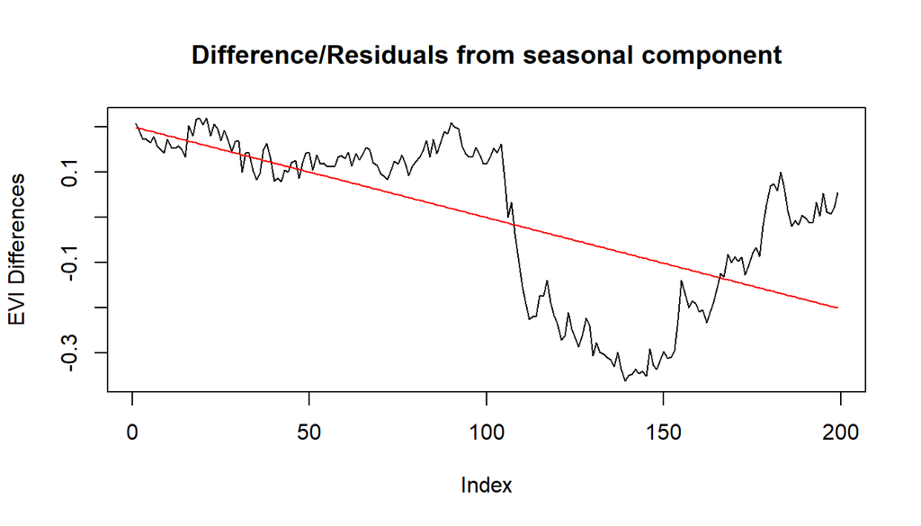

## Example analysis

Looking at the cumulated sum of the model’s residuals shows that they do not fluctuate around 0, which we expected in our hypothesis.

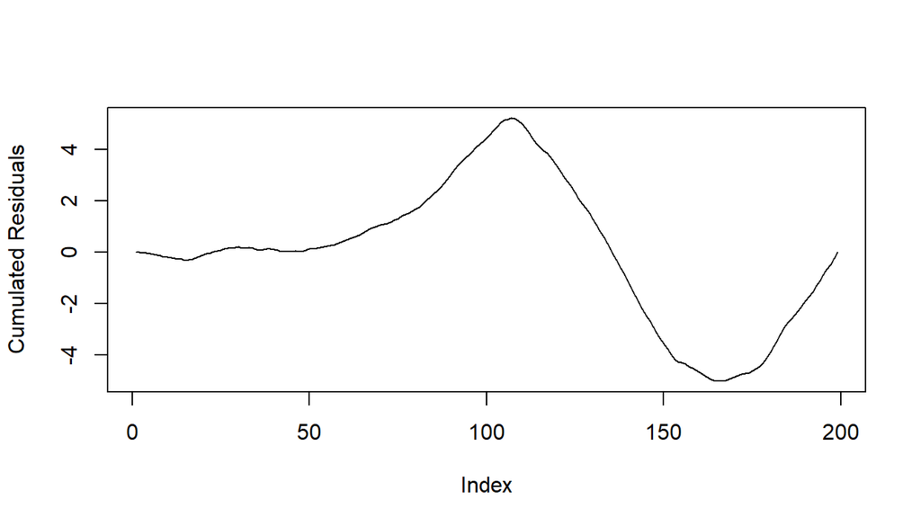

By thresholding the cumulated residuals based on a given confidence level, we can find a breakpoint around t=107.

## Example analysis

A better model:

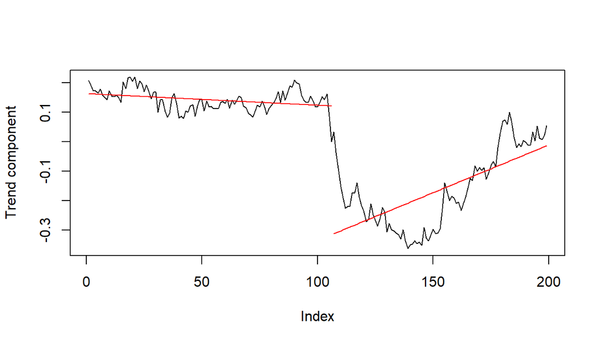

## Example analysis

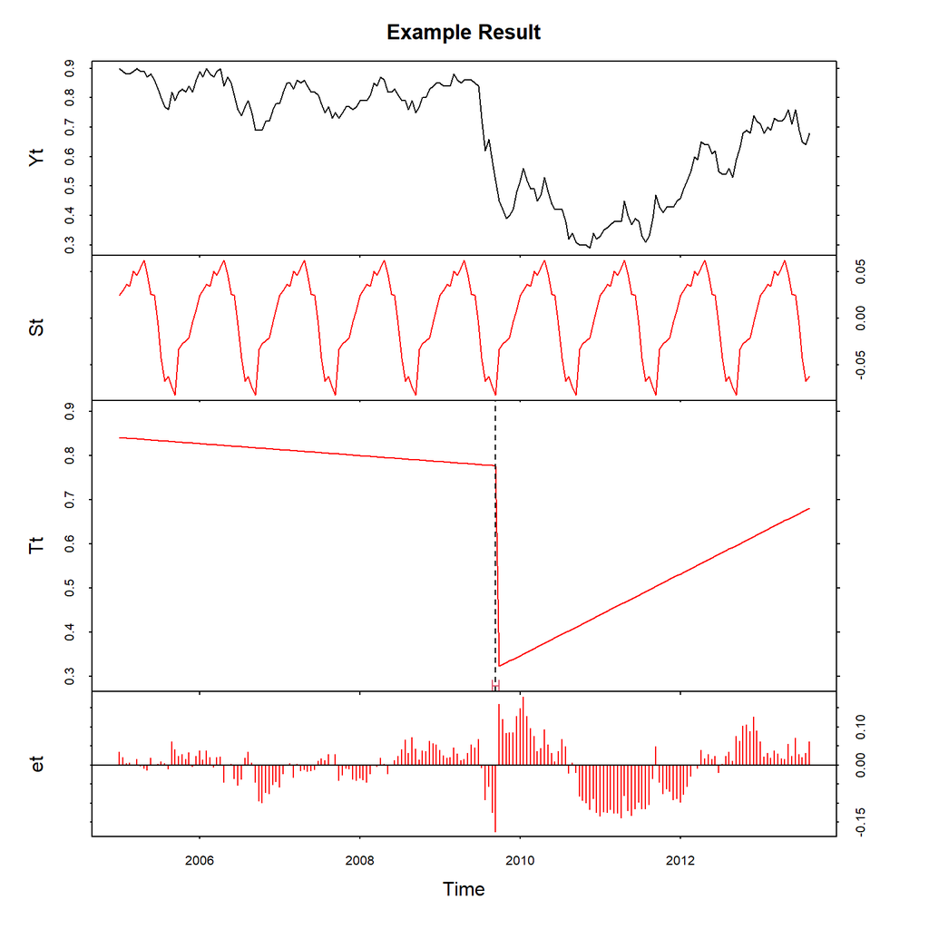

## Literature (sidetrack)

1. Verbesselt, J., Hyndman, R., Newnham, G., & Culvenor, D. (2010). Detecting trend and seasonal changes in satellite image time series. Remote Sensing of Environment, 114, 106-115. DOI: 10.1016/j.rse.2009.08.014.
2. R. B. Cleveland, W. S. Cleveland, J.E. McRae, and I. Terpenning (1990) STL: A Seasonal-Trend Decomposition Procedure Based on Loess. Journal of Official Statistics, 6, 3-73.
3. W. S. Cleveland, E. Grosse and W. M. Shyu (1992) Local regression models. Chapter 8 of Statistical Models in S eds J.M. Chambers and T.J. Hastie, Wadsworth and Brooks/Cole.